# Supervised Learning and Visualization Practical 2

2. Run the code below to generate data. There will be three vectors in your environment. Put them in a data frame for entering it in a `ggplot()` call using either the `data.frame()` or the `tibble()` function. Give informative names and make sure the types are correct (use the `as.<type>()` functions). Name the result `gg_students`.

```r
set.seed(1234)
student_grade  <- rnorm(32, 7)
student_number <- round(runif(32) * 2e6 + 5e6)
programme      <- sample(c("Science", "Social Science"), 32, replace = TRUE)
```

```r
gg_students <- data.frame("grade" = student_grade, "number" = as.character(student_number), program = as.factor(programme))
```

3. Plot the first homeruns_plot again, but map the Hits to the y-axis and the HmRun to the x-axis instead

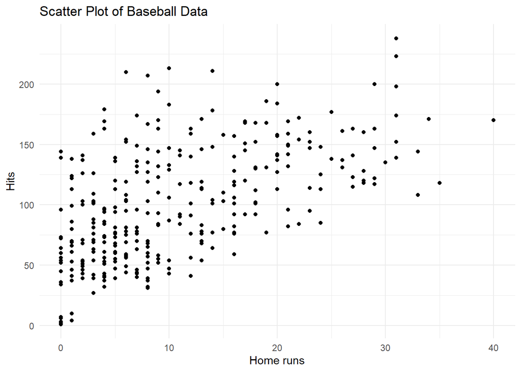

```r
ggplot(Hitters, aes(x = HmRun, y = Hits))+
  geom_point()+
  labs(x = "Home runs", y = "Hits", title = "Scatter Plot of Baseball Data")+
  theme_minimal()
```

4. Recreate the same plot once more, but now also map the variable League to the colour aesthetic and the variable Salary to the size aesthetic.

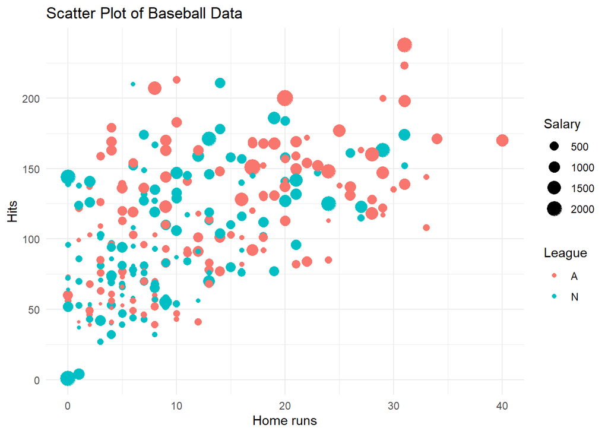

```r
ggplot(Hitters, aes(x = HmRun, y = Hits, color = League, size = Salary))+
  geom_point()+
  labs(x = "Home runs", y = "Hits", title = "Scatter Plot of Baseball Data")+
  theme_minimal()
```

5. Look at the many different geoms on the reference website.
6. Use `geom_histogram()` to create a histogram of the grades of the students in the `gg_students` dataset. Play around with the `binwidth` argument of the `geom_histogram()` function.

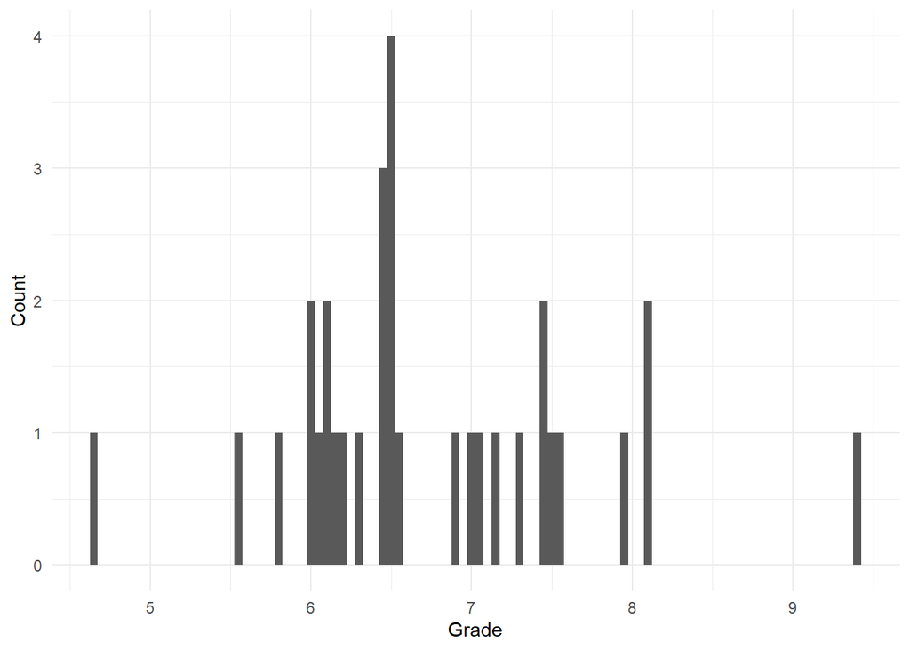

```r
ggplot(gg_students, aes(x = grade))+
  geom_histogram(binwidth = 0.05)+
  labs(x = "Grade", y = "Count")+
  theme_minimal()
```

7. Use `geom_density()` to create a density plot of the grades of the students in the `gg_students` dataset. Add the argument `fill = "light seagreen"` to `geom_density()`.

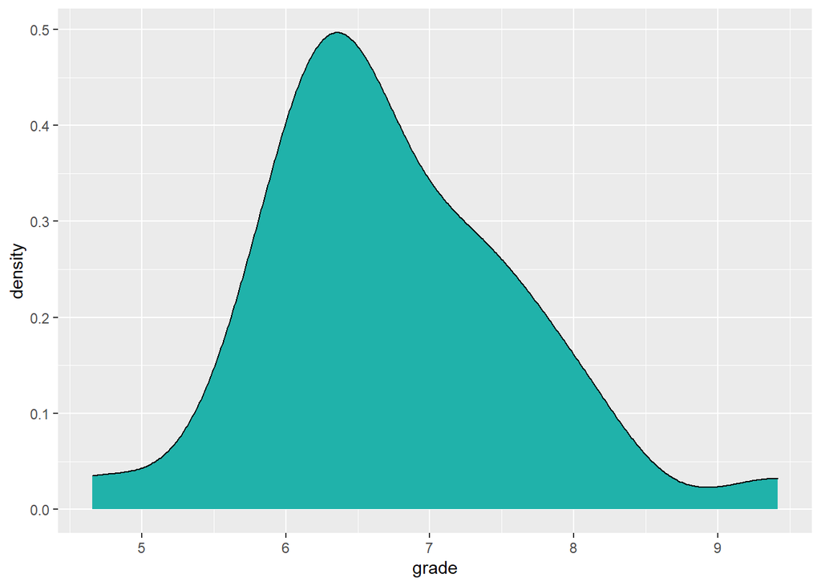

```r
ggplot(gg_students, aes(x = grade))+
  geom_density(fill = "light seagreen")
```

8. Add rug marks to the density plot through `geom_rug()`. You can edit the `colour` and `size` of the rug marks using those arguments within the geom_rug() function.

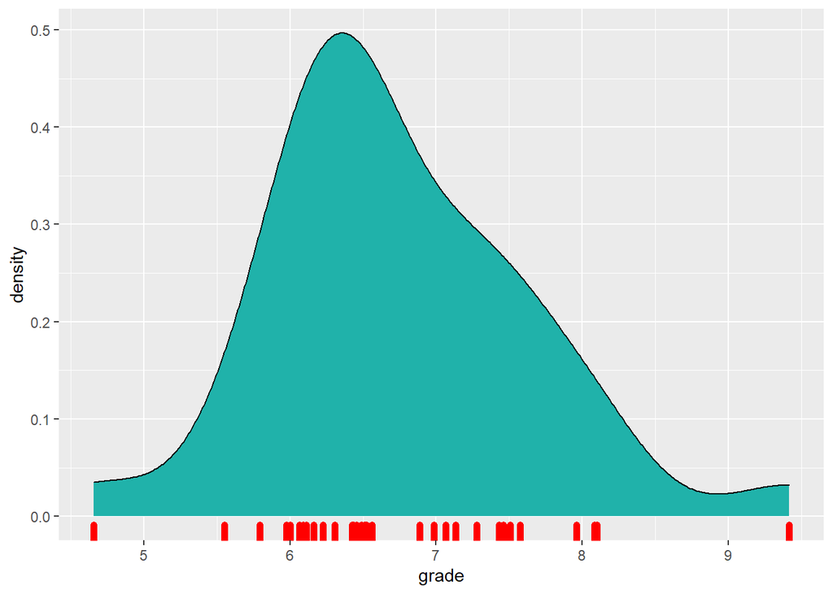

```r
ggplot(gg_students, aes(x = grade))+
  geom_density(fill = "light seagreen")+
  geom_rug(color = 'red', size = 2)
```

9. Increase the data to ink ratio by removing the y axis label, setting the theme to `theme_minimal()`, and removing the border of the density polygon. Also set the limits of the x-axis to go from 0 to 10 using the `xlim()` function, because those are the plausible values for a student grade.

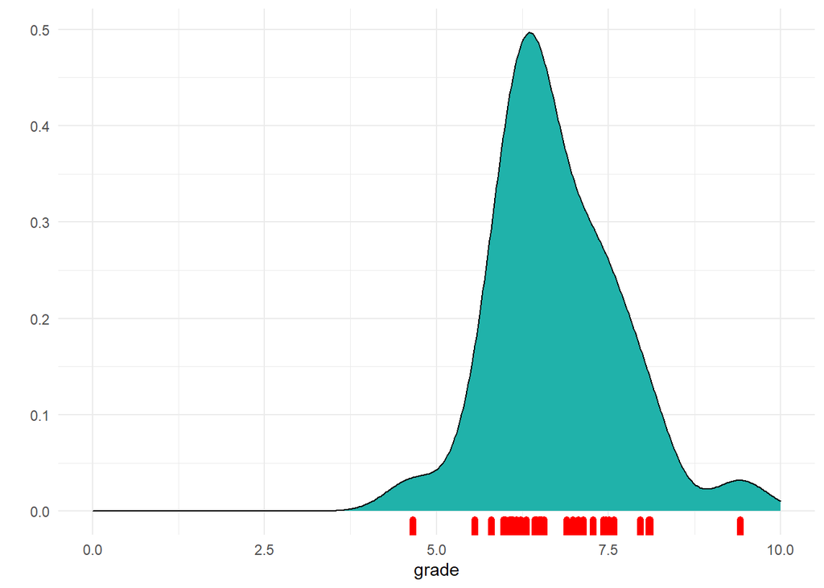

```r
ggplot(gg_students, aes(x = grade))+
  geom_density(fill = "light seagreen")+
  geom_rug(color = 'red', size = 2)+
  labs(y = "") +
  xlim(0, 10)+
  theme_minimal()
```

10. Create a boxplot of student grades per programme in the `gg_students` dataset you made earlier: map the `programme` variable to the x position and the `grade` to the y position. For extra visual aid, you can additionally map the `programme` variable to the `fill aesthetic`.

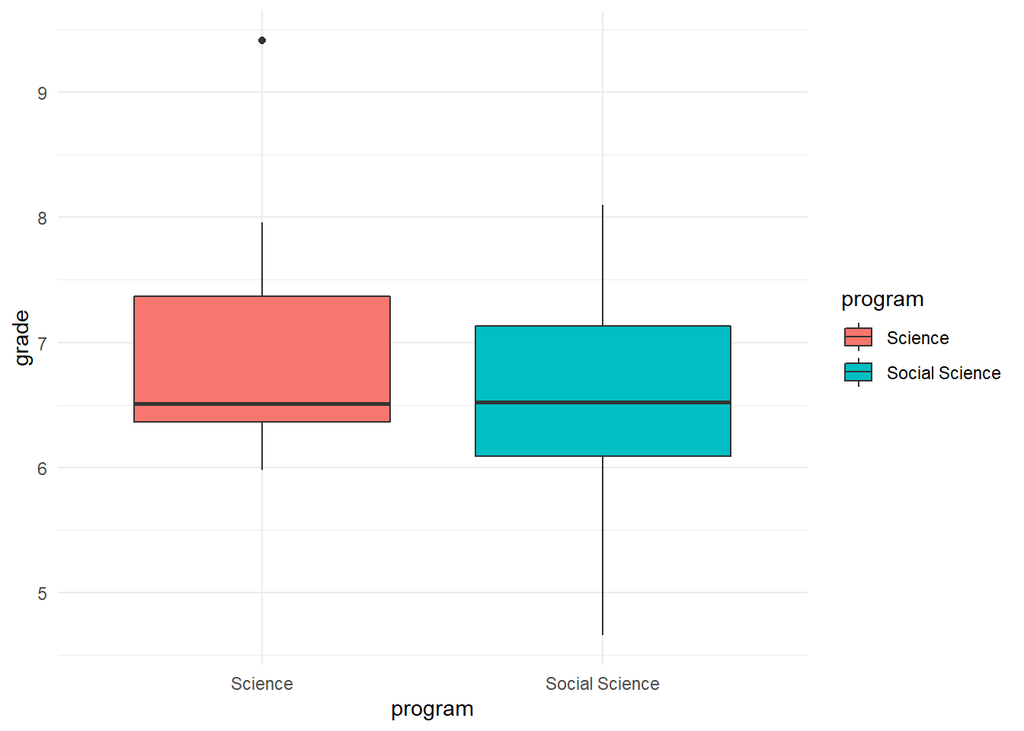

```r
ggplot(gg_students, aes(x = program, y = grade, fill = program))+
  geom_boxplot()+
  theme_minimal()
```

11. What do each of the horizontal lines in the boxplot mean? What do the vertical lines (whiskers) mean?

The horizontal lines in the center of the box indicate the median, and the borders of each box indicate the interquantile range (IQR). The vertical lines are called whiskers and the upper and lower whiskers represent scores outside the middle 50%.